# 09_Practical; Wk. 10

Ryan Greenup 17805315

27 September 2019

# (Wk 11) Introduction to Data Science

Material of Tue 13 May 2019, week 11

## 2 Groups

The `kmeans()` function performs $k$-Means Clustering in R, so first create some clustered data:

```r
set.seed(2)
x <- matrix(rnorm(50*2), ncol = 2)
x[1:25, 1] <- x[1:25, 1] + 3
x[1:25, 2] <- x[1:25, 2] - 4
```

This will mean that half of $X_1$ is 3 higher and half of $X_2$ is 4 lower.

Now in order to perform $k$-menas clustering with $K=2$:

```r
km.out <- kmeans(x, 2, nstart = 20)
```

The assignments of the 50 observatoins are contained in `$cluster`:

```r
km.out$cluster
```

```
##  [1] 1 1 1 1 1 1 1 1 1 1 1 1 1 1 1 1 1 1 1 1 1 1 1 1 1 2 2 2 2 2 2 2 2 2 2
## [36] 2 2 2 2 2 2 2 2 2 2 2 2 2 2 2
```

This can be plotted:

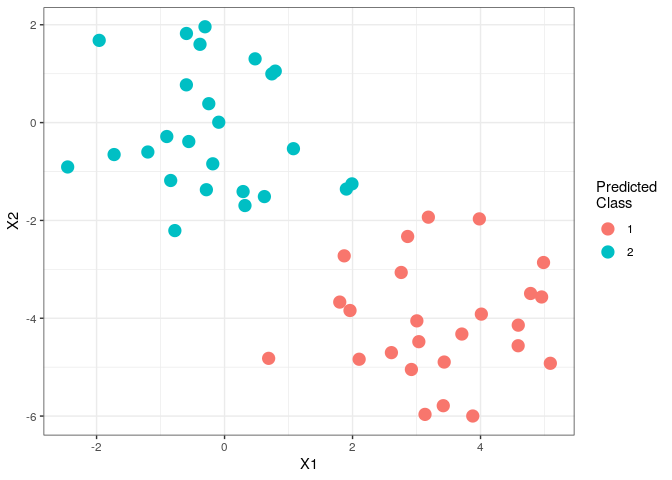

```r
colnames(x) <- c("X1", "X2")
x2ClustPred <- as_tibble(x)
x2ClustPred$K2Pred <- factor(km.out$cluster, levels = c(1, 2), ordered = FALSE)

ggplot(x2ClustPred, aes(x = X1, y = X2, col = K2Pred)) +
  geom_point( size = 4) +
  theme_bw() +
  labs(col = "Predicted\nClass", main = "Classification Prediction")
```

If there were more dimensions, it would then be appropriate to use PCA to reduce it to 2 dimensions and then plot the clusters like that.

### Three Groups

In this case we knew there would be two groups because we created it like that, however when ordinarily performing unsupervised learning this wouldn’t be known.

Trying three groups:

```r
set.seed(4)
km3mod <- kmeans(x, 3, nstart = 20)
#km3mod
```

This can be plotted by performing:

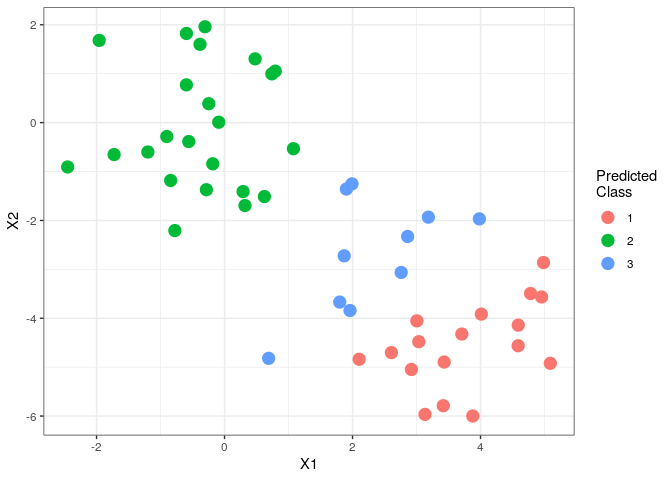

```r
colnames(x) <- c("X1", "X2")
x3ClustPred <- as_tibble(x)
x3ClustPred$K3Pred <- factor(km3mod$cluster, levels = c(1, 2, 3), ordered = FALSE)

ggplot(x3ClustPred, aes(x = X1, y = X2, col = K3Pred)) +
  geom_point( size = 4) +
  theme_bw() +
  labs(col = "Predicted\nClass", main = "Classification Prediction")
```

In this case the algorithm chooses points in between to represent the third class.

## Best Cluster Size

To run the `kmeans()` multiplie times with a different initial cluster the `nstart` parameter is used.

If a value of `nstart` greater than one is used then the clustering will be performed using multiple random assignments in step 1 of the K-means algorighm (p. 388) and the function will report only the best results, thes results are more likely to correspond to the minimum RSS, which is difficult to find.

So for example we can repeat the k-means and choose the distribution that most corresponds to the model that minimises the RSS by choosing a sufficiently large `nstart` value:

```r
set.seed(3)
km.out <- kmeans(x, 5, nstart = 1)
km.out$tot.withinss
```

```
## [1] 64.16453
```

```r
km.out <- kmeans(x, 5, nstart = 50)
km.out$tot.withinss
```

```
## [1] 50.89555
```

Remember to set the seed because otherwise the initial cluster assignments cannot be replicated and the K-means may not be fully reproducable.